# Mouse1: lineage reconstruction

Tested using R version 4.0.2, sessionInfo at the bottom

Output files generated throughout this workbook:  
* `precluster_filtered.txt` is a large file containing all aligned data remaining after the organizational and QC steps of the "Section 1" portion  
* `final_classifications.txt` concisely stores cell type (i.e. singlet, doublet, unmatched etc) and cloneID if matched singlet  
* `final_singlets.txt` is a large file containing all info from alignment pipeline for final remaining singlets after all steps  
- this includes all aligned transcripts as individual rows and full barcode sequences  
* `final_editing_data.txt` is used for phylogeny building scripts downstream

### Section 1: Filter aligned barcode sequence data to find real cells and static barcodes

#### Provide input files and perform intial parsing, cleanup, and filtering

1. Provide barcode aligned files for each sample (files ending in .stats)
2. Provide a 10x barcode (i.e. cellID) whitelist
   - can be from Seurat or Monocle transcriptional workflow or simply 10x's v3 cellranger 3' mRNA whitelist
   - we use our own Seurat whitelist, as we're only interested in cells with corresponding single cell transcriptional data
3. Provide a project name, used for naming output files

#### Initiate a summary table to append info on during each filtration step

|  | Step | Cells | IntIDs | Cell_IntID_Combos | Cell_UMI_Combos | Reads | Clusters |
| --- | --- | --- | --- | --- | --- | --- | --- |
| 1 | Aligned to CRISPR barcode | NA | NA | NA | 1258597 | 58166575 | NA |
| 2 | Present in thresholded transcriptome data | 18392 | NA | NA | 940872 | 32151846 | NA |
| 3 | Remove incomplete intIDs | 17980 | 3980 | 87651 | 806151 | 28378259 | NA |

#### Remove cell + static barcode (Cell-IntID) combos that fall below a transcript (UMI) threshold

- This removes combos that are probably PCR errors or that are ambient background in an otherwise cell-containing droplet

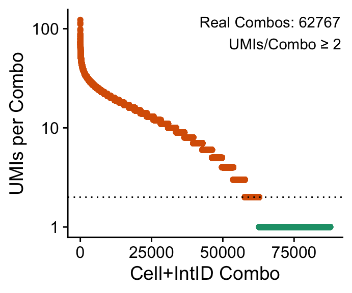

|  | Step | Cells | IntIDs | Cell_IntID_Combos | Cell_UMI_Combos | Reads | Clusters |
| --- | --- | --- | --- | --- | --- | --- | --- |
| 1 | Aligned to CRISPR barcode | NA | NA | NA | 1258597 | 58166575 | NA |
| 2 | Present in thresholded transcriptome data | 18392 | NA | NA | 940872 | 32151846 | NA |
| 3 | Remove incomplete intIDs | 17980 | 3980 | 87651 | 806151 | 28378259 | NA |
| 4 | Remove Cell-intIDs with < 2 UMIs | 16924 | 272 | 62767 | 781267 | 27977004 | NA |

#### Filter static barcodes (IntIDs) by the average # of transcripts (UMIs) they have across cells

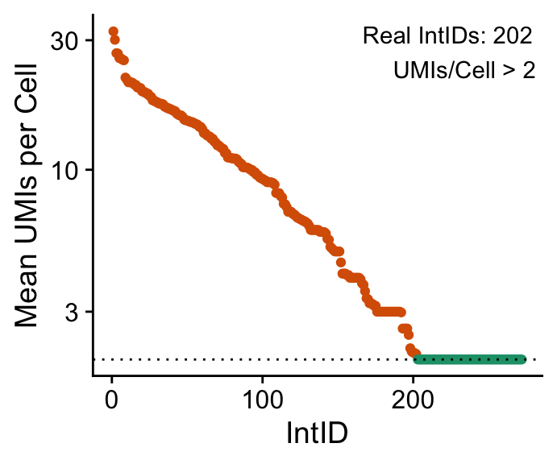

|  | Step | Cells | IntIDs | Cell_IntID_Combos | Cell_UMI_Combos | Reads | Clusters |
| --- | --- | --- | --- | --- | --- | --- | --- |
| 1 | Aligned to CRISPR barcode | NA | NA | NA | 1258597 | 58166575 | NA |
| 2 | Present in thresholded transcriptome data | 18392 | NA | NA | 940872 | 32151846 | NA |
| 3 | Remove incomplete intIDs | 17980 | 3980 | 87651 | 806151 | 28378259 | NA |
| 4 | Remove Cell-intIDs with < 2 UMIs | 16924 | 272 | 62767 | 781267 | 27977004 | NA |
| 5 | Remove intIDs =< 2 mean UMIs/cell | 16919 | 202 | 62666 | 781065 | 27974319 | NA |

#### Filter static barcodes (IntIDs) again by the number of cells in which they are recovered

- Setup mostly to remove IntIDs/barcodes that connect few cells to each other and are hence uninformative or sequencing errors

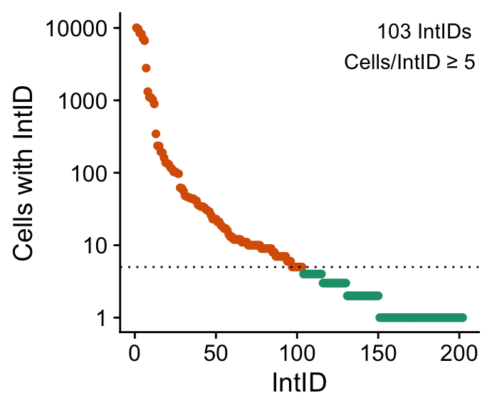

|  | Step | Cells | IntIDs | Cell_IntID_Combos | Cell_UMI_Combos | Reads | Clusters |
| --- | --- | --- | --- | --- | --- | --- | --- |
| 1 | Aligned to CRISPR barcode | NA | NA | NA | 1258597 | 58166575 | NA |
| 2 | Present in thresholded transcriptome data | 18392 | NA | NA | 940872 | 32151846 | NA |
| 3 | Remove incomplete intIDs | 17980 | 3980 | 87651 | 806151 | 28378259 | NA |
| 4 | Remove Cell-intIDs with < 2 UMIs | 16924 | 272 | 62767 | 781267 | 27977004 | NA |
| 5 | Remove intIDs =< 2 mean UMIs/cell | 16919 | 202 | 62666 | 781065 | 27974319 | NA |
| 6 | Remove intIDs found in < 5 cells | 16861 | 103 | 62481 | 779881 | 27906164 | NA |

### Section 2: Discover clones and classify cells into clones via static barcode content

#### Cluster cells by their static barcode contents

- Cells are compared to one another by their static barcode overlap
- Complete-linkage hierarchal clustering is used
  - i.e. every cell starts as its own cluster, pair-wise comparisons are made and larger and larger clusters form
- Takes around 15min to run for 4-5k cells, 3-5min for 1-2k cells
- Set the number of clusters to call (and highlight in red) manually - trial and error is required here
- Overclustering is best at this initial step, i.e. visually check that no clearly seperate clusters are being incorrectly grouped together
- This inital clustering is processed downstream and used to call real clones

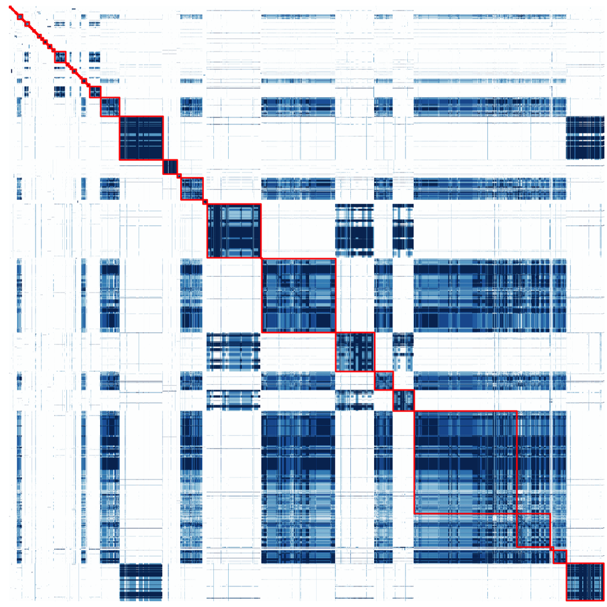

#### Cluster collapsing and cleanup to identify clones

- Clusters defined by identical sets or subsets of static barcodes are collapsed automatically
- After automatic cluster collapsing, the data must be checked manually
- Any uncollapsed clusters need to be manually collapsed (this is usually only the case for few to no clusters)
- Cells are then classified into finalized clusters (i.e. clones) & inter-clonal doublets and unmatched cells are identified
- Note the % of unmatched cells and doublets
  - The % of unmatched cells shouldn't be very high (less than a few percent)
  - The % of doublets shouldn't be very high (2-20% depending on cells loaded on 10x, check their guidelines)
  - High doublet or unmatched percentages would suggest an error clone calling, resulting in misclassification of cells
- Finally clones not rooted in the PT are filtered
  - While these clones may simply be due to undersampling, they may also be artifacts of the injection process
  - Only a few small clones are usually filtered by this step (very few overall cells are filtered)

[output not shown]

#### Visualize filtered singlets grouped by static clone

- Again replot how cells' static barcode contents overlap with only singlets displayed now
- Cells are grouped by clone and within a clone, cells are arranged from most to least missing information moving left to right along the diagonal
  - Hence why on the top left of a clonal square there will be individual solid squares, i.e. cells that only have one static barcode captured
  - The # of individual squares is the same as the number of static barcodes that define that clone
  - For example, the largest clone in the top left is defined by 7 static barcodes, and most of the cells in this clone have multiple barcodes captured
- Note that only the PT is displayed below since no more than 6-8k cells can be run on a normal computer and the PT is most diverse and contains all clones

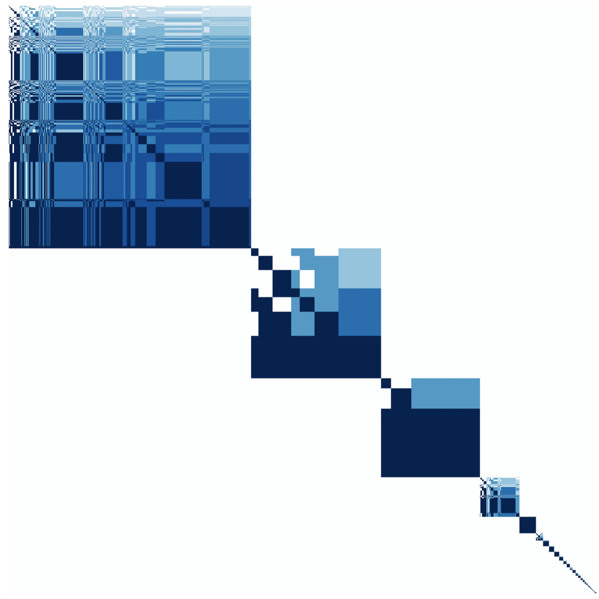

|  | Step | Cells | IntIDs | Cell_IntID_Combos | Cell_UMI_Combos | Reads | Clusters |
| --- | --- | --- | --- | --- | --- | --- | --- |
| 1 | Aligned to CRISPR barcode | NA | NA | NA | 1258597 | 58166575 | NA |
| 2 | Present in thresholded transcriptome data | 18392 | NA | NA | 940872 | 32151846 | NA |
| 3 | Remove incomplete intIDs | 17980 | 3980 | 87651 | 806151 | 28378259 | NA |
| 4 | Remove Cell-intIDs with < 2 UMIs | 16924 | 272 | 62767 | 781267 | 27977004 | NA |
| 5 | Remove intIDs =< 2 mean UMIs/cell | 16919 | 202 | 62666 | 781065 | 27974319 | NA |
| 6 | Remove intIDs found in < 5 cells | 16861 | 103 | 62481 | 779881 | 27906164 | NA |
| 7 | Matched singlets (rm inter-clonal doublets) | 15087 | 65 | 55614 | 697224 | 24500731 | 30 |

### Section 3: Organize and finalize outputs for downstream analyses

#### Expression level for each static barcode

- i.e. number of UMIs per static barcode per Cell
- Each data point is a unique cell-barcode pair

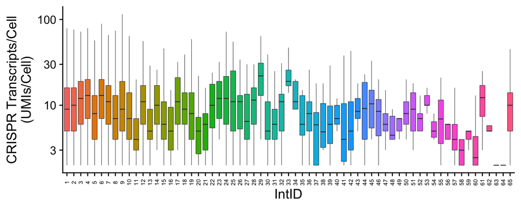

#### Unique mutatagenized CRISPR barcode alleles per cell for each static barcode

- Jitter plot where each data point is a unique cell-barcode-allele pair, with mean overlayed as a dash
- Ideally each singlet has only one unique allele per static barcode after noise filtration (alleles comprising <25% of transcripts are filtered)
  - noise can be in the form of transcriptional, PCR, or sequencing errors present in a small fraction of transcripts detected for cell-barcode pair
- This is the case for most cells, but exceptions occur in the form of intraclonal doublets and barcode copy-number gain
  - i.e. since these PDAC cells are chromosomally unstable, there may be barcodes that have an increased copy number
- We id potentially duplicated or tripliacted barcodes and then id potential cell doublets

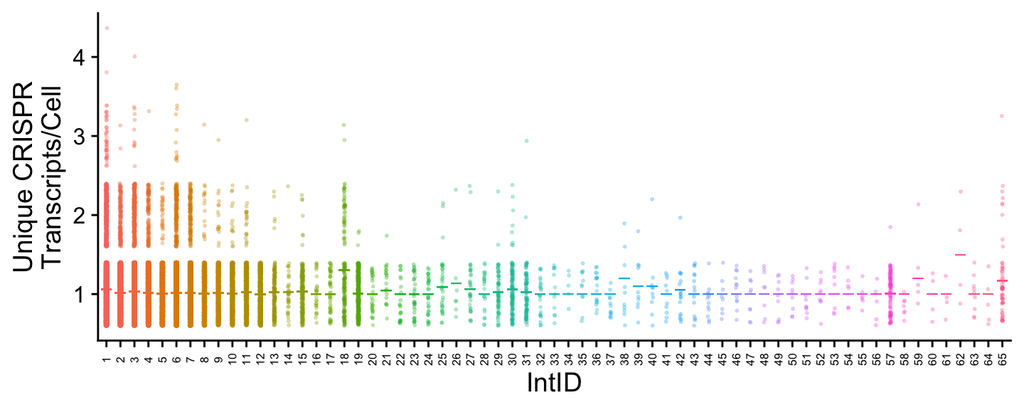

#### Summarize data and finalize and generate 3 output files

- `final_classifications.txt` concisely stores cell type (i.e. single, doublet etc) and cloneID if matched singlet
- `final_singlets.txt` is a large file containing all info from alignment pipeline for final singlets
  - this includes all aligned transcripts as individual rows and full barcode sequences
- `final_editing_data.txt` is used for phylogeny building scripts downstream
  - here barcodes with potential copy-number gains are removed
  - only the top mutagenized transcript is retained for each cell-barcode pair

| status | amount | percent |
| --- | --- | --- |
| final_singlet | 14452 | 85.7% |
| doublet | 2018 | 12.0% |
| no_PT_singlet | 300 | 1.8% |
| unmatched | 91 | 0.5% |

|  | Step | Cells | IntIDs | Cell_IntID_Combos | Cell_UMI_Combos | Reads | Clusters |
| --- | --- | --- | --- | --- | --- | --- | --- |
| 1 | Aligned to CRISPR barcode | NA | NA | NA | 1258597 | 58166575 | NA |
| 2 | Present in thresholded transcriptome data | 18392 | NA | NA | 940872 | 32151846 | NA |
| 3 | Remove incomplete intIDs | 17980 | 3980 | 87651 | 806151 | 28378259 | NA |
| 4 | Remove Cell-intIDs with < 2 UMIs | 16924 | 272 | 62767 | 781267 | 27977004 | NA |
| 5 | Remove intIDs =< 2 mean UMIs/cell | 16919 | 202 | 62666 | 781065 | 27974319 | NA |
| 6 | Remove intIDs found in < 5 cells | 16861 | 103 | 62481 | 779881 | 27906164 | NA |
| 7 | Matched singlets (rm inter-clonal doublets) | 15087 | 65 | 55614 | 697224 | 24500731 | 30 |
| 8 | Singlets remaining (rm intra-clonal doublets) | 14452 | 64 | 53422 | 665625 | 23533964 | 29 |